# ULR models

## Intro

here we try to combine a frequency and average ckaim size model into an incurred model. we observe that there is a rate at which claims are transitioning back to zero. our intention is to model net non-zero claims above some very low threshold.

```r
library(devtools)
remove.packages(c("StanHeaders", "rstan"))
##install_github("hsbadr/rstan/StanHeaders@develop")
install.packages("StanHeaders", repos = c("https://mc-stan.org/r-packages/", getOption("repos")))
install.packages("RcppEigen", repos = c("https://mc-stan.org/r-packages/", getOption("repos")))
#install_version("RcppEigen", "0.3.3.9.1")
##install_github("hsbadr/rstan/rstan/rstan@develop")
install.packages("rstan", repos = c("https://mc-stan.org/r-packages/", getOption("repos")))
install_github("paul-buerkner/brms",dependencies = TRUE)
```

## set cmdstan to build models in the background

```r
library(cmdstanr)

register_knitr_engine()
```

## model development

after looking into the problem further, it might be smart to set it up as an ODE model first.

### example

the example below is from the stan documentation. the syntax of the functions has changed recently, making it harder to just use what in on the internet. A great example from the older syntax is from Marcus Gessman on mages blog [mages blog](https://magesblog.com/post/2021-02-08-fitting-multivariate-ode-models-with-brms/).

```stan
functions {
  vector sho(real t,
             vector y,
             real theta) {
    vector[2] dydt;
    dydt[1] = y[2];
    dydt[2] = -y[1] - theta * y[2];
    return dydt;
  }
}
data {
  int<lower=1> T;
  vector[2] y0;
  real t0;
  array[T] real ts;
  real theta;
}
model {
}
generated quantities {
  vector[2] y_sim[T] = ode_rk45(sho, y0, t0, ts, theta);
  // add measurement error
  for (t in 1:T) {
    y_sim[t, 1] += normal_rng(0, 0.1);
    y_sim[t, 2] += normal_rng(0, 0.1);
  }
}
```

### my first try

I will try to get something working below.

#### some basic points

Start by just saying the the integral of the pdf is the lambda for any given time period, where the number of reported non-zero claims (excluding those that go back to zero) at any point in time is a poisson distribution with mean lambda. An analytic solution exists in terms of ult*lognormal_cdf(t,mu,sigma) where Ult is the ultimate expected number of claims that were ever positive.
$$\frac{\partial \lambda}{\partial t} =
U.lognormal_{pdf}(t,\mu,\sigma)$$
the analytic solution is then
$$\lambda(t) =
U.lognormal_{cdf}(t,\mu,\sigma)$$

where $\lambda$ is the expected cumulative (i.e. current actual) number of non zero claims ever reported at a given point in time. When time is infinity the expected claim count is $U$ (the ultimate expected number).

We will implement this as a standard poisson frequency model where we count the incremental number of reported non-nil claims.

Similarly, we can represent the binomial rate of non-zero claims falling back to zero. This is unfortunately required at times as we are modelling net claims and there can easily be a significant number of “negative IBNR” in the late tail of the claim count triangulations.
$$\frac{\partial p}{\partial t} =
U_plognormal_{pdf}(t,\mu_p,\sigma_p)$$
Then we can show the analytic solution for p:
$$p(t)=U_plognormal_{cdf}(t,\mu,\sigma)$$
but unfortunately:
$$N_-(a)=\int_0^a\frac{\partial p}{\partial t}N(t)
\partial t$$
With a binomial distribution, the calculation is harder. Now we introduce the count of claims and the expected count of claims for the number of positive reported claims $N_+(t)$, the number of claims that have fallen back to zero $N_-(t)$ and the current actual number of non-zero claims $N$.An alternative for $N_-$ might now be:
$$\frac{\partial \overline N_-}{\partial
t}=\overline N \frac {\partial p}{\partial t}$$
which is only true over many samples but is easier to solve for. Then we can represent a differential equation perhaps:
$$\frac{\partial \overline{N}_-}{\partial t} =
\overline N(t).U_p.lognormal_{pdf}(t,\mu_p,\sigma_p)$$
which involves no discrete numbers.

The first step of the process we can state more easily:
$$N_+(t)=poisson(\lambda(t))$$
A simple poisson sample. So
$$\overline{N}_+(t)=\lambda(t)$$
A much easier calculation.

Calculating $N(t)$ seems the hardest. We shall approximate $\overline N(t)$ with a differential equation:
$$\frac {\partial \overline N}{\partial t}=\frac
{\partial \overline N_+}{\partial t} - \frac {\partial \overline
N_-}{\partial t}$$
which simplifies to:
$$\frac {\partial \overline N}{\partial
t}=U.lognormal_{pdf}(t,\mu,\sigma) - \overline
N(t).U_p.lognormal_{pdf}(t,\mu_p,\sigma_p)$$
which contains only continuous numbers and can be solved for in stan using the PDE solver or the numerical integrator.

#### start putting together a model

```stan
  // we solve for #>0 at any point in time t
vector N_ode(real t,//time
             vector N,// expected # of non-zero claims and expected # dropping to zero at time t. must be a vector so 2d. This is what is being solved for.
             real U,
             real U_p,
             real mu,
             real sigma,
             real mu_p,
             real sigma_p
             ) {
    vector[2] dNdt;
    dNdt[1] = U*lognormal_lpdf(t|mu,sigma)-N[1]*U_p*lognormal_lpdf(t|mu_p,sigma_p);// cumulative # claims >0
    dNdt[2] = N[1]*U_p*lognormal_lpdf(t|mu_p,sigma_p);
    return dNdt;// cumulative # claims dropped back to zero
}
// modify signature for calls from the integrator to output N
real[] N_ode_int(real t,
                  real [] N,  // both N and N_neg
                  real [] theta, // model parameters
              real [] x_r, int[] x_i
             ) {
    real dNdt[2];
    real U = theta[1];
    real U_p = theta[2];
    real mu = theta[3];
    real sigma = theta[4];
    real mu = theta[5];
    real sigma_p = theta[6];

    dNdt[1] = U*lognormal_lpdf(t|mu,sigma)-N[1]*U_p*lognormal_lpdf(t|mu_p,sigma_p);// cumulative # claims >0
    dNdt[2] = N[1]*U_p*lognormal_lpdf(t|mu_p,sigma_p);// cumulative # claims dropped back to zero
    return dNdt;
}

// Integrate ODE to solve for N at a point in time
real N_int(real t,
        real U,
        real U_p,
        real mu,
        real sigma,
        real mu_p,
        real sigma_p
        ) {
  real N0[2];     // Initial values
  real par[6];  // Parameters
  real N[1, 2];   // ODE solution at time t
  // Set initial values. There should be no claims initially
  N0[1] = 0;
  N0[2] = 0;
  // Set parameters
  par[1] = U;
  par[2] = U_p;
  par[3] = mu;
  par[4] = sigma;
  par[5] = mu_p;
  par[6] = sigma_p;

  // Solve ODEs
  //array[,] real integrate_ode_rk45(function ode, array[] real initial_state, real initial_time, array[] real times, array[] real theta, array[] real x_r, array[] int x_i, real rel_tol, real abs_tol, int max_num_steps)
  N = integrate_ode_rk45(N_ode_int, //function that will receicve par as input
                         N0, // N and N- at t=0
                         0, // initial t=0
                         rep_array(t, 1), //array of times at which to find N
                         par,// set of parameters for ode function
                         rep_array(0.0, 0), // not needed real data
                         rep_array(1, 1),// not needed int data
                         1e-6, 1e-5, 1e3); // max steps
  // Return relevant values
  return N[1];// returns N only
}

// Integrate ODE to solve for N- at a point in time
real N_neg_int(real t,
        real U,
        real U_p,
        real mu,
        real sigma,
        real mu_p,
        real sigma_p
        ) {
  real N0[2];     // Initial values
  real par[6];  // Parameters
  real N[1, 2];   // ODE solution at time t
  // Set initial values. There should be no claims initially
  N0[1] = 0;
  N0[2] = 0;
  // Set parameters
  par[1] = U;
  par[2] = U_p;
  par[3] = mu;
  par[4] = sigma;
  par[5] = mu_p;
  par[6] = sigma_p;

  // Solve ODEs
  //array[,] real integrate_ode_rk45(function ode, array[] real initial_state, real initial_time, array[] real times, array[] real theta, array[] real x_r, array[] int x_i, real rel_tol, real abs_tol, int max_num_steps)
  N = integrate_ode_rk45(N_ode_int, //function that will receicve par as input
                         N0, // N and N- at t=0
                         0, // initial t=0
                         rep_array(t, 1), //array of times at which to find N
                         par,// set of parameters for ode function
                         rep_array(0.0, 0), // not needed real data
                         rep_array(1, 1),// not needed int data
                         1e-6, 1e-5, 1e3); // max steps
  // Return relevant values
  return N[2];// returns N- only
}
```

put this code into a text string and set up a brms formula

```r
library(brms)
functions = "// we solve for #>0 at any point in time t
vector N_ode(real t,//time
             vector N,// expected # of non-zero claims and expected # dropping to zero at time t. must be a vector so 2d. This is what is being solved for.
             real U,
             real U_p,
             real mu,
             real sigma,
             real mu_p,
             real sigma_p
             ) {
    vector[2] dNdt;
    dNdt[1] = U*lognormal_lpdf(t|mu,sigma)-N[1]*U_p*lognormal_lpdf(t|mu_p,sigma_p);// cumulative # claims >0
    dNdt[2] = N[1]*U_p*lognormal_lpdf(t|mu_p,sigma_p);
    return dNdt;// cumulative # claims dropped back to zero
}
// modify signature for calls from the integrator to output N
real[] N_ode_int(real t,
                  real [] N,  // both N and N_neg
                  real [] theta, // model parameters
              real [] x_r, int[] x_i
             ) {
    real dNdt[2];
    real U = theta[1];
    real U_p = theta[2];
    real mu = theta[3];
    real sigma = theta[4];
    real mu = theta[5];
    real sigma_p = theta[6];

    dNdt[1] = U*lognormal_lpdf(t|mu,sigma)-N[1]*U_p*lognormal_lpdf(t|mu_p,sigma_p);// cumulative # claims >0
    dNdt[2] = N[1]*U_p*lognormal_lpdf(t|mu_p,sigma_p);// cumulative # claims dropped back to zero
    return dNdt;
}

// Integrate ODE to solve for N at a point in time
real N_int(real t,
        real U,
        real U_p,
        real mu,
        real sigma,
        real mu_p,
        real sigma_p
        ) {
  real N0[2];     // Initial values
  real par[6];  // Parameters
  real N[1, 2];   // ODE solution at time t
  // Set initial values. There should be no claims initially
  N0[1] = 0;
  N0[2] = 0;
  // Set parameters
  par[1] = U;
  par[2] = U_p;
  par[3] = mu;
  par[4] = sigma;
  par[5] = mu_p;
  par[6] = sigma_p;

  // Solve ODEs
  //array[,] real integrate_ode_rk45(function ode, array[] real initial_state, real initial_time, array[] real times, array[] real theta, array[] real x_r, array[] int x_i, real rel_tol, real abs_tol, int max_num_steps)
  N = integrate_ode_rk45(N_ode_int, //function that will receicve par as input
                         N0, // N and N- at t=0
                         0, // initial t=0
                         rep_array(t, 1), //array of times at which to find N
                         par,// set of parameters for ode function
                         rep_array(0.0, 0), // not needed real data
                         rep_array(1, 1),// not needed int data
                         1e-6, 1e-5, 1e3); // max steps
  // Return relevant values
  return N[1];// returns N only
}

// Integrate ODE to solve for N- at a point in time
real N_neg_int(real t,
        real U,
        real U_p,
        real mu,
        real sigma,
        real mu_p,
        real sigma_p
        ) {
  real N0[2];     // Initial values
  real par[6];  // Parameters
  real N[1, 2];   // ODE solution at time t
  // Set initial values. There should be no claims initially
  N0[1] = 0;
  N0[2] = 0;
  // Set parameters
  par[1] = U;
  par[2] = U_p;
  par[3] = mu;
  par[4] = sigma;
  par[5] = mu_p;
  par[6] = sigma_p;

  // Solve ODEs
  //array[,] real integrate_ode_rk45(function ode, array[] real initial_state, real initial_time, array[] real times, array[] real theta, array[] real x_r, array[] int x_i, real rel_tol, real abs_tol, int max_num_steps)
  N = integrate_ode_rk45(N_ode_int, //function that will receicve par as input
                         N0, // N and N- at t=0
                         0, // initial t=0
                         rep_array(t, 1), //array of times at which to find N
                         par,// set of parameters for ode function
                         rep_array(0.0, 0), // not needed real data
                         rep_array(1, 1),// not needed int data
                         1e-6, 1e-5, 1e3); // max steps
  // Return relevant values
  return N[2];// returns N- only
}

real lognormal_lccdf_mod(real a,real b,real c){
  return lognormal_lccdf(a|b,c);
}

"

# writing the formula we are essentially declaring what the parameters need to be called
formula <-  bf(
   N_pos_increment ~ lambda,
   nlf(lambda ~ log(Upois) +log_diff_exp( lognormal_lccdf_mod(tprev,mupois,sigmapois), lognormal_lccdf_mod(t,mupois,sigmapois)) ),# std incremental poisson model for N+ using modified version of lccdf for syntax and numerical accuracy in the tail
   nlf(Upois ~ exp(Upoisstd)),
   mupois~1,
   Upoisstd ~1,
  nlf(sigmapois~exp(sigmapoisstd)),
  sigmapoisstd~1,
  family = poisson(),
  nl=TRUE)+
  bf(N_neg_increment | trials(Nprev) ~ pbinom , nlf(pbinom~(N_neg_int(t,Upois,Ubin,mupois,sigmapois,mubin,sigmabin)-N_neg_int(tprev,Upois,Ubin,mupois,sigmapois,mubin,sigmabin))/N_int(tprev,Upois,Ubin,mupois,sigmapois,mubin,sigmabin)),# approximation based on available data
  # unfortunately the line above doesn't work as parameters cannot be shared between the poisson and binomial model within the brms syntax. so we must add it manually unfortunately
     nlf(Ubin~exp(Ubinstd)),
  nlf(sigmabin~exp(sigmabinstd)),
  mubin~1,
  Ubinstd~1,
  sigmabinstd~1,
  nlf(Upois ~ exp(Upoisstd)),
  mupois~1,
  Upoisstd ~1,
  nlf(sigmapois~exp(sigmapoisstd)),
  sigmapoisstd~1,
  family = binomial("identity"),
  nl = TRUE )

# specify std normal non-centred priors
mypriors <- c(
  prior(normal(0, 1),resp = "Nposincrement", nlpar = "Upoisstd"),
  prior(normal(0, 1), resp = "Nnegincrement",nlpar = "Ubinstd"),
  prior(normal(0, 1), resp = "Nposincrement",nlpar = "sigmapoisstd"),
  prior(normal(0, 1), resp = "Nnegincrement",nlpar = "sigmabinstd"),
  prior(normal(0, 1), resp = "Nposincrement",nlpar = "mupois"),
  prior(normal(0, 1), resp = "Nnegincrement",nlpar = "mubin"))
```

#### generate some data

I try never to use real data initially as I need to confirm that the models can recover parameters as expected and that the synthetic data can be contrived to look like the real world data.

```r
library(dplyr)
nt = 50 #number of time points
Upois = 50 # expected ultimate number of claims
# trial and error with parameters to get the performance of interest
mupois=2
sigmapois =0.7
Ubin = 2
mubin = 2.5
sigmabin=0.5
k=10
standata = data.frame(row = 1:nt,t=1:nt,
                      tprev = (1:nt) -1)%>%
                      #N_pos_increment ~ log(Upois) +log_diff_exp( lognormal_lccdf(tprev,mupois,sigmapois), lognormal_lccdf(t,mupois,sigmapois))
            mutate(
                      N_pos_increment = rpois(nt,exp(log(Upois) +log( x =
                                                                                                                  plnorm(t,mupois,sigmapois)-
                                                                                                                  plnorm(tprev,mupois,sigmapois)))),
                      pois_cdf = plnorm(t,mupois,sigmapois),
                      bin_cdf = plnorm(t,mubin,sigmabin),

                        #N_neg_increment | trials(Nprev) ~ (N_neg_int(t,Upois,Ubin,mupois,sigmapois,mubin,sigmabin)-N_neg_int(tprev,Upois,Ubin,mupois,sigmapois,mubin,sigmabin))/N_int(tprev,Upois,Ubin,mupois,sigmapois,mubin,sigmabin)
                      p_bin = Ubin*(plnorm(t,mubin,sigmabin)- plnorm(tprev,mubin,sigmabin)),
                      p_bin_softp = -(log(1+exp(-k*(p_bin-1)))/k -1)

            )
for (i in 1:nt){
  standata$N_pos[i] = if(i != 1)  standata$N_pos_increment[i]+standata$N_pos[i-1] else standata$N_pos_increment[i]
  standata$N_neg_increment[i]= if(i != 1)  rbinom(1,standata$N[i-1],standata$p_bin_softp[i]) else 0
  standata$N_neg[i]= if(i != 1)  standata$N_neg_increment[i] +standata$N_neg[i-1] else standata$N_neg_increment[i]
  standata$N[i] = if(i != 1)  standata$N_pos_increment[i]-standata$N_neg_increment[i]+standata$N[i-1] else standata$N_pos_increment[i]-standata$N_neg_increment[i]
  standata$Nprev[i] = if(i != 1)  standata$N[i-1] else 0
}
standata$tprev[1]=0.01 # fix an initial conditions problem
```

####run the model

```r
prior_set = get_prior(formula,prior = mypriors,
  stanvars = stanvar(scode = functions, block = "functions"),
  data = standata, backend = "cmdstan")
```

```
## Setting 'rescor' to FALSE by default for this model
```

```r
model <- brm(
  formula,prior = mypriors,
  stanvars = stanvar(scode = functions, block = "functions"),
  data = standata, backend = "cmdstan",
  control = list(adapt_delta = 0.99),
  seed = 1234, iter = 1000,
  chains = 4, cores = 6,
  file = "frequencyCMDStan.rds")
```

ok. An error. it turns out that there is no easy way to share the poisson model parameters with the binomial model in a way that I can see without modifying the stan code directly…

Easiest way is to write my own family for the binomial section that pulls in the other shared parameters.

```r
# nlp_Nnegincrement_Ubin[n] naming conventions

binomsharedpars <- custom_family(
                    "binomsharedpars", dpars = c("mu","mubin","sigmabin"), # actually mu is                really the Ubin for the binomial
                    links = c("log","identity","log"),
                    type = "int",# lpmf vs lpdf
                    vars = c("vint1[n]", # Nprev that we are passing as additional data
                             "vreal1[n]",# t
                             "vreal2[n]",# tprev
                             "nlp_Nposincrement_Upois[n]", #Upois
                             "nlp_Nposincrement_mupois[n]", #mupois
                             "nlp_Nposincrement_sigmapois[n]" #sigmapois
                             ) # the additional parameters to calculate                   pbinom~(N_neg_int(t,Upois,Ubin,mupois,sigmapois,mubin,sigmabin)-N_neg_int(                tprev,Upois,Ubin,mupois,sigmapois,mubin,sigmabin))/N_int(tprev,Upois,Ubin,               mupois,sigmapois,mubin,sigmabin)
              )
```

now we need to modify the functions section further to include the required functions to calculate the loglikelihood for the new family

```stan
// we solve for #>0 at any point in time t
vector N_ode(real t,//time
             vector N,// expected # of non-zero claims and expected # dropping to zero at time t. must be a vector so 2d. This is what is being solved for.
             real U,
             real U_p,
             real mu,
             real sigma,
             real mu_p,
             real sigma_p
             ) {
    vector[2] dNdt;
    dNdt[1] = U*lognormal_lpdf(t|mu,sigma)-N[1]*U_p*lognormal_lpdf(t|mu_p,sigma_p);// cumulative # claims >0
    dNdt[2] = N[1]*U_p*lognormal_lpdf(t|mu_p,sigma_p);
    return dNdt;// cumulative # claims dropped back to zero
}
// modify signature for calls from the integrator to output N
real[] N_ode_int(real t,
                  real [] N,  // both N and N_neg
                  real [] theta, // model parameters
              real [] x_r, int[] x_i
             ) {
    real dNdt[2];
    real U = theta[1];
    real U_p = theta[2];
    real mu = theta[3];
    real sigma = theta[4];
    real mu = theta[5];
    real sigma_p = theta[6];

    dNdt[1] = U*lognormal_lpdf(t|mu,sigma)-N[1]*U_p*lognormal_lpdf(t|mu_p,sigma_p);// cumulative # claims >0
    dNdt[2] = N[1]*U_p*lognormal_lpdf(t|mu_p,sigma_p);// cumulative # claims dropped back to zero
    return dNdt;
}

// Integrate ODE to solve for N at a point in time
real N_int(real t,
        real U,
        real U_p,
        real mu,
        real sigma,
        real mu_p,
        real sigma_p
        ) {
  real N0[2];     // Initial values
  real par[6];  // Parameters
  real N[1, 2];   // ODE solution at time t
  // Set initial values. There should be no claims initially
  N0[1] = 0;
  N0[2] = 0;
  // Set parameters
  par[1] = U;
  par[2] = U_p;
  par[3] = mu;
  par[4] = sigma;
  par[5] = mu_p;
  par[6] = sigma_p;

  // Solve ODEs
  //array[,] real integrate_ode_rk45(function ode, array[] real initial_state, real initial_time, array[] real times, array[] real theta, array[] real x_r, array[] int x_i, real rel_tol, real abs_tol, int max_num_steps)
  N = integrate_ode_rk45(N_ode_int, //function that will receicve par as input
                         N0, // N and N- at t=0
                         0, // initial t=0
                         rep_array(t, 1), //array of times at which to find N
                         par,// set of parameters for ode function
                         rep_array(0.0, 0), // not needed real data
                         rep_array(1, 1),// not needed int data
                         1e-6, 1e-5, 1e3); // max steps
  // Return relevant values
  return N[1];// returns N only
}

// Integrate ODE to solve for N- at a point in time
real N_neg_int(real t,
        real U,
        real U_p,
        real mu,
        real sigma,
        real mu_p,
        real sigma_p
        ) {
  real N0[2];     // Initial values
  real par[6];  // Parameters
  real N[1, 2];   // ODE solution at time t
  // Set initial values. There should be no claims initially
  N0[1] = 0;
  N0[2] = 0;
  // Set parameters
  par[1] = U;
  par[2] = U_p;
  par[3] = mu;
  par[4] = sigma;
  par[5] = mu_p;
  par[6] = sigma_p;

  // Solve ODEs
  //array[,] real integrate_ode_rk45(function ode, array[] real initial_state, real initial_time, array[] real times, array[] real theta, array[] real x_r, array[] int x_i, real rel_tol, real abs_tol, int max_num_steps)
  N = integrate_ode_rk45(N_ode_int, //function that will receicve par as input
                         N0, // N and N- at t=0
                         0.0, // initial t=0
                         rep_array(t, 1), //array of times at which to find N
                         par,// set of parameters for ode function
                         rep_array(0.0, 0), // not needed real data
                         rep_array(1, 1),// not needed int data
                         1e-6, 1e-5, 1e3); // max steps
  // Return relevant values
  return N[2];// returns N- only
}

real binomsharedpars_lpmf(int Nnegincrement,
                          real Ubin,
                          real mubin,
                          real sigmabin,
                          int Nprev,
                          real t,
                          real tprev,
                          real Upois,
                          real mupois,
                          real sigmapois,
                          ){
    return binomial_lpmf(Nnegincrement | Nprev,(N_neg_int(t,Upois,Ubin,mupois,sigmapois,mubin,sigmabin)-N_neg_int(tprev,Upois,Ubin,mupois,sigmapois,mubin,sigmabin))/N_int(tprev,Upois,Ubin,mupois,sigmapois,mubin,sigmabin));
}


real lognormal_lccdf_mod(real a,real b,real c){
  return lognormal_lccdf(a|b,c);
}
```

use this as our stanvars for the functions section

```r
stan_functions = "// we solve for #>0 at any point in time t
vector N_ode(real t,//time
             vector N,// expected # of non-zero claims and expected # dropping to zero at time t. must be a vector so 2d. This is what is being solved for.
             real U,
             real U_p,
             real mu,
             real sigma,
             real mu_p,
             real sigma_p
             ) {
    vector[2] dNdt;
    dNdt[1] = U*lognormal_lpdf(t|mu,sigma)-N[1]*U_p*lognormal_lpdf(t|mu_p,sigma_p);// cumulative # claims >0
    dNdt[2] = N[1]*U_p*lognormal_lpdf(t|mu_p,sigma_p);
    return dNdt;// cumulative # claims dropped back to zero
}
// modify signature for calls from the integrator to output N
real[] N_ode_int(real t,
                  real [] N,  // both N and N_neg
                  real [] theta, // model parameters
              real [] x_r, int[] x_i
             ) {
    real dNdt[2];
    real U = theta[1];
    real U_p = theta[2];
    real mu = theta[3];
    real sigma = theta[4];
    real mu_p = theta[5];
    real sigma_p = theta[6];

    dNdt[1] = U*lognormal_lpdf(t|mu,sigma)-N[1]*U_p*lognormal_lpdf(t|mu_p,sigma_p);// cumulative # claims >0
    dNdt[2] = N[1]*U_p*lognormal_lpdf(t|mu_p,sigma_p);// cumulative # claims dropped back to zero
    return dNdt;
}

// Integrate ODE to solve for N at a point in time
real N_int(real t,
        real U,
        real U_p,
        real mu,
        real sigma,
        real mu_p,
        real sigma_p
        ) {
  real N0[2];     // Initial values
  real par[6];  // Parameters
  real N[1, 2];   // ODE solution at time t
  real returnpar;
  // Set initial values. There should be no claims initially
  N0[1] = 0;
  N0[2] = 0;
  // Set parameters
  par[1] = U;
  par[2] = U_p;
  par[3] = mu;
  par[4] = sigma;
  par[5] = mu_p;
  par[6] = sigma_p;

  // Solve ODEs
  //array[,] real integrate_ode_rk45(function ode, array[] real initial_state, real initial_time, array[] real times, array[] real theta, array[] real x_r, array[] int x_i, real rel_tol, real abs_tol, int max_num_steps)
  N = integrate_ode_rk45(N_ode_int, //function that will receicve par as input
                         N0, // N and N- at t=0
                         0.0, // initial t=0
                         rep_array(t, 1), //array of times at which to find N
                         par,// set of parameters for ode function
                         rep_array(0.0, 0), // not needed real data
                         rep_array(1, 1),// not needed int data
                         1e-6, 1e-5, 1e3); // max steps
  // Return relevant values
  returnpar = N[1,1];// returns N only
  return returnpar;
}

// Integrate ODE to solve for N- at a point in time
real N_neg_int(real t,
        real U,
        real U_p,
        real mu,
        real sigma,
        real mu_p,
        real sigma_p
        ) {
  real N0[2];     // Initial values
  real par[6];  // Parameters
  real N[1, 2];   // ODE solution at time t
  real returnpar;
  // Set initial values. There should be no claims initially
  N0[1] = 0;
  N0[2] = 0;
  // Set parameters
  par[1] = U;
  par[2] = U_p;
  par[3] = mu;
  par[4] = sigma;
  par[5] = mu_p;
  par[6] = sigma_p;

  // Solve ODEs
  //array[,] real integrate_ode_rk45(function ode, array[] real initial_state, real initial_time, array[] real times, array[] real theta, array[] real x_r, array[] int x_i, real rel_tol, real abs_tol, int max_num_steps)
  N = integrate_ode_rk45(N_ode_int, //function that will receicve par as input
                         N0, // N and N- at t=0
                         0.0 , // initial t=0
                         rep_array(t, 1), //array of times at which to find N
                         par,// set of parameters for ode function
                         rep_array(0.0, 0), // not needed real data
                         rep_array(1, 1),// not needed int data
                         1e-6, 1e-5, 1e3); // max steps
  // Return relevant values
  returnpar = N[1,2];// returns N- only
  return returnpar;
}

real binomsharedpars_lpmf(int Nnegincrement,
                          real Ubin,
                          real mubin,
                          real sigmabin,
                          int Nprev,
                          real t,
                          real tprev,
                          real Upois,
                          real mupois,
                          real sigmapois
                          ){
    real p;
    p=(N_neg_int(t,Upois,Ubin,mupois,sigmapois,mubin,sigmabin)-N_neg_int(tprev,Upois,Ubin,mupois,sigmapois,mubin,sigmabin))/N_int(tprev,Upois,Ubin,mupois,sigmapois,mubin,sigmabin);
    p = -(log(1+exp(-10*(p-1)))/10 -1);// use softplus to block approach to 1
    return binomial_lpmf(Nnegincrement | Nprev,p);
}


real lognormal_lccdf_mod(real a,real b,real c){
  return lognormal_lccdf(a|b,c);
}

"
```

now we are ready to try to build the brms model again

```r
# writing the formula we are essentially declaring what the parameters need to be called
formula <-  bf(
   N_pos_increment ~ lambda,
   nlf(lambda ~ log(Upois) +log_diff_exp( lognormal_lccdf_mod(tprev,mupois,sigmapois), lognormal_lccdf_mod(t,mupois,sigmapois)) ),# std incremental poisson model for N+ using modified version of lccdf for syntax and numerical accuracy in the tail
   nlf(Upois ~ exp(Upoisstd*log(20)+log(50))),
   mupois~1,
   Upoisstd ~1,
  nlf(sigmapois~exp(sigmapoisstd)),
  sigmapoisstd~1,
  family = poisson(),
  nl=TRUE)+
  bf(N_neg_increment | vint(Nprev)+vreal(t,tprev) ~ 1 ,
     mubin~1,
     sigmabin~1,
     family = binomsharedpars)

# specify std normal non-centred priors
mypriors <- c(
  prior(normal(0, 1),resp = "Nposincrement", nlpar = "Upoisstd"),
  #prior(normal(0, 1), resp = "Nnegincrement",dpar = "mu"),
  prior(normal(0, 1), resp = "Nposincrement",nlpar = "sigmapoisstd"),
  prior(normal(0, 1), class = "Intercept",resp = "Nnegincrement",dpar = "sigmabin"),
  prior(normal(0, 1), resp = "Nposincrement",nlpar = "mupois"),
  prior(normal(0, 1), class = "Intercept",resp = "Nnegincrement",dpar = "mubin")
  )
```

####run the new model

```r
prior_set = get_prior(formula,prior = mypriors,
  stanvars = stanvar(scode = stan_functions, block = "functions"),
  data = standata, backend = "cmdstan")
```

```
## Setting 'rescor' to FALSE by default for this model
```

```r
model <- brm(
  formula,
  prior = mypriors,
  stanvars = stanvar(scode = stan_functions, block = "functions"),
  data = standata, backend = "cmdstan",
  control = list(adapt_delta = 0.99),
  seed = 1234, iter = 1000,
  chains = 4, cores = 6,
  file = "frequencyCMDStan.rds")
```

This version fails to initialise, so we will modify the code and do some debugging.

```r
stan_functions = "// we solve for #>0 at any point in time t
vector N_ode(real t,//time
             vector N,// expected # of non-zero claims and expected # dropping to zero at time t. must be a vector so 2d. This is what is being solved for.
             real U,
             real U_p,
             real mu,
             real sigma,
             real mu_p,
             real sigma_p
             ) {
    vector[2] dNdt;
    dNdt[1] = U*lognormal_lpdf(t|mu,sigma)-N[1]*U_p*lognormal_lpdf(t|mu_p,sigma_p);// cumulative # claims >0
    dNdt[2] = N[1]*U_p*lognormal_lpdf(t|mu_p,sigma_p);
    return dNdt;// cumulative # claims dropped back to zero
}
// modify signature for calls from the integrator to output N
real[] N_ode_int(real t,
                  real [] N,  // both N and N_neg
                  real [] theta, // model parameters
              real [] x_r, int[] x_i
             ) {
    real dNdt[2];
    real U = theta[1];
    real U_p = theta[2];
    real mu = theta[3];
    real sigma = theta[4];
    real mu_p = theta[5];
    real sigma_p = theta[6];

    dNdt[1] = U*lognormal_lpdf(t|mu,sigma)-N[1]*U_p*lognormal_lpdf(t|mu_p,sigma_p);// cumulative # claims >0
    dNdt[2] = N[1]*U_p*lognormal_lpdf(t|mu_p,sigma_p);// cumulative # claims dropped back to zero
    return dNdt;
}

// Integrate ODE to solve for N at a point in time
real N_int(real t,
        real U,
        real U_p,
        real mu,
        real sigma,
        real mu_p,
        real sigma_p
        ) {
  real N0[2];     // Initial values
  real par[6];  // Parameters
  real N[1, 2];   // ODE solution at time t
  real returnpar;
  // Set initial values. There should be no claims initially
  N0[1] = 0;
  N0[2] = 0;
  // Set parameters
  par[1] = U;
  par[2] = U_p;
  par[3] = mu;
  par[4] = sigma;
  par[5] = mu_p;
  par[6] = sigma_p;

  // Solve ODEs
  //array[,] real integrate_ode_rk45(function ode, array[] real initial_state, real initial_time, array[] real times, array[] real theta, array[] real x_r, array[] int x_i, real rel_tol, real abs_tol, int max_num_steps)
  N = integrate_ode_rk45(N_ode_int, //function that will receicve par as input
                         N0, // N and N- at t=0
                         0.0, // initial t=0
                         rep_array(t, 1), //array of times at which to find N
                         par,// set of parameters for ode function
                         rep_array(0.0, 0), // not needed real data
                         rep_array(1, 1),// not needed int data
                         1e-6, 1e-5, 1e3); // max steps
  // Return relevant values
  returnpar = N[1,1];// returns N only
  return returnpar;
}

// Integrate ODE to solve for N- at a point in time
real N_neg_int(real t,
        real U,
        real U_p,
        real mu,
        real sigma,
        real mu_p,
        real sigma_p
        ) {
  real N0[2];     // Initial values
  real par[6];  // Parameters
  real N[1, 2];   // ODE solution at time t
  real returnpar;
  // Set initial values. There should be no claims initially
  N0[1] = 0;
  N0[2] = 0;
  // Set parameters
  par[1] = U;
  par[2] = U_p;
  par[3] = mu;
  par[4] = sigma;
  par[5] = mu_p;
  par[6] = sigma_p;

  // Solve ODEs
  //array[,] real integrate_ode_rk45(function ode, array[] real initial_state, real initial_time, array[] real times, array[] real theta, array[] real x_r, array[] int x_i, real rel_tol, real abs_tol, int max_num_steps)
  N = integrate_ode_rk45(N_ode_int, //function that will receicve par as input
                         N0, // N and N- at t=0
                         0.0 , // initial t=0
                         rep_array(t, 1), //array of times at which to find N
                         par,// set of parameters for ode function
                         rep_array(0.0, 0), // not needed real data
                         rep_array(1, 1),// not needed int data
                         1e-6, 1e-5, 1e3); // max steps
  // Return relevant values
  returnpar = N[1,2];// returns N- only
  return returnpar;
}

real binomsharedpars_lpmf(int Nnegincrement,
                          real Ubin,
                          real mubin,
                          real sigmabin,
                          int Nprev,
                          real t,
                          real tprev,
                          real Upois,
                          real mupois,
                          real sigmapois
                          ){
    real p;
    p= Ubin*exp(log_diff_exp(lognormal_lccdf(tprev|mubin,sigmabin), lognormal_lccdf(t|mubin,sigmabin)));
    p = -(log(1+exp(-10*(p-1)))/10 -1);// use softplus to block approach to 1
    return binomial_lpmf(Nnegincrement | Nprev,p);
}


real lognormal_lccdf_mod(real a,real b,real c){
  return lognormal_lccdf(a|b,c);
}

"
```

this worked but it would be better if the n in the binomial distribution was Nprev + Nposincrement as this is strictly the maximum number of Nnegicrement claims in a period.

We also are not using the ode solver at this stage, so we will need to import the additional data to solve that including N.

# Define a family

adding a new statistical family definition in order to pass the needed variables across between the models

```r
# nlp_Nnegincrement_Ubin[n] naming conventions

binomsharedpars <- custom_family(
                    "binomsharedpars", dpars = c("mu","mubin","sigmabin"), # actually mu is                really the Ubin for the binomial
                    links = c("log","identity","log"),
                    type = "int",# lpmf vs lpdf
                    vars = c("vint1[n]", # Nprev
                             "vint2[n]", # N
                             "vreal1[n]",# t
                             "vreal2[n]",# tprev
                             "nlp_Nposincrement_Upois[n]", #Upois
                             "nlp_Nposincrement_mupois[n]", #mupois
                             "nlp_Nposincrement_sigmapois[n]" #sigmapois
                             )
              )
```

# modify functions

and now modify the functions for the family definition and solve ODE

```r
stan_functions = "// we solve for #>0 at any point in time t
vector N_ode(real t,//time
             vector N,// expected # of non-zero claims and expected # dropping to zero at time t. must be a vector so 2d. This is what is being solved for.
             real U,
             real U_p,
             real mu,
             real sigma,
             real mu_p,
             real sigma_p
             ) {
    vector[2] dNdt;
    dNdt[1] = exp(log_diff_exp(log(U)+lognormal_lpdf(t|mu,sigma),log(N[1])+log(U_p)+lognormal_lpdf(t|mu_p,sigma_p)));// cumulative # claims >0
    dNdt[2] = N[1]*U_p*exp(lognormal_lpdf(t|mu_p,sigma_p));
    print(dNdt[1],\" \",dNdt[2]);
    return dNdt;// cumulative # claims dropped back to zero
}
// modify signature for calls from the integrator to output N
real[] N_ode_int(real t,
                  real [] N,  // both N and N_neg
                  real [] theta, // model parameters
              real [] x_r, int[] x_i
             ) {
    real dNdt[2];
    real U = theta[1];
    real U_p = theta[2];
    real mu = theta[3];
    real sigma = theta[4];
    real mu_p = theta[5];
    real sigma_p = theta[6];

    dNdt[1] = U*exp(lognormal_lpdf(t|mu,sigma))-N[1]*U_p*exp(lognormal_lpdf(t|mu_p,sigma_p));// gradient of cumulative # claims >0
    dNdt[2] = N[1]*U_p*exp(lognormal_lpdf(t|mu_p,sigma_p));// gradient of cumulative # claims dropped back to zero
    return dNdt;
}

// Integrate ODE to solve for N at a point in time
real N_int(real t,
        real U,
        real U_p,
        real mu,
        real sigma,
        real mu_p,
        real sigma_p
        ) {
  real N0[2];     // Initial values
  real par[6];  // Parameters
  real N[1, 2];   // ODE solution at time t
  real returnpar;

  // check gradients can be calculated
  N0[1] = U*exp(lognormal_lpdf(t|mu,sigma))-1.0*U_p*exp(lognormal_lpdf(t|mu_p,sigma_p));// gradient of cumulative # claims >0
    N0[2] = 1.0*U_p*exp(lognormal_lpdf(t|mu_p,sigma_p));// gradient of cumulative # claims dropped back to zero
  if(is_nan(N0[1])||is_nan(N0[2])) print(N0[1],\" \",N0[2]);
  // Set initial values. There should be no claims initially
  N0[1] = 0;
  N0[2] = 0;
  // Set parameters
  par[1] = U;
  par[2] = U_p;
  par[3] = mu;
  par[4] = sigma;
  par[5] = mu_p;
  par[6] = sigma_p;



  // Solve ODEs
  //array[,] real integrate_ode_rk45(function ode, array[] real initial_state, real initial_time, array[] real times, array[] real theta, array[] real x_r, array[] int x_i, real rel_tol, real abs_tol, int max_num_steps)
  N = integrate_ode_rk45(N_ode_int, //function that will receicve par as input
                         N0, // N and N- at t=0
                         0.0, // initial t=0
                         rep_array(t, 1), //array of times at which to find N
                         par,// set of parameters for ode function
                         rep_array(0.0, 0), // not needed real data
                         rep_array(1, 1),// not needed int data
                         1e-6, 1e-5, 1e3); // max steps
  // Return relevant values
  returnpar = N[1,1];// returns N only
  return returnpar;
}

// Integrate ODE to solve for N- at a point in time
real N_neg_int(real t,
        real U,
        real U_p,
        real mu,
        real sigma,
        real mu_p,
        real sigma_p
        ) {
  real N0[2];     // Initial values
  real par[6];  // Parameters
  real N[1, 2];   // ODE solution at time t
  real returnpar;
  // Set initial values. There should be no claims initially
  N0[1] = 0;
  N0[2] = 0;
  // Set parameters
  par[1] = U;
  par[2] = U_p;
  par[3] = mu;
  par[4] = sigma;
  par[5] = mu_p;
  par[6] = sigma_p;

  // Solve ODEs
  //array[,] real integrate_ode_rk45(function ode, array[] real initial_state, real initial_time, array[] real times, array[] real theta, array[] real x_r, array[] int x_i, real rel_tol, real abs_tol, int max_num_steps)
  N = integrate_ode_rk45(N_ode_int, //function that will receive par as input
                         N0, // N and N- at t=0
                         0.0 , // initial t=0
                         rep_array(t, 1), //array of times at which to find N
                         par,// set of parameters for ode function
                         rep_array(0.0, 0), // not needed real data
                         rep_array(1, 1),// not needed int data
                         1e-6, 1e-5, 1e3); // max steps
  // Return relevant values
  returnpar = N[1,2];// returns N- only
  return returnpar;
}

real binomsharedpars_lpmf(int Nnegincrement,
                          real Ubin,
                          real mubin,
                          real sigmabin,
                          int Nprev,
                          int N,
                          real t,
                          real tprev,
                          real Upois,
                          real mupois,
                          real sigmapois
                          ){
    real p;
    //p= Ubin*exp(log_diff_exp(lognormal_lccdf(tprev|mubin,sigmabin), lognormal_lccdf(t|mubin,sigmabin)));
    p=N_int(t,Upois,Ubin,mupois,sigmapois,mubin,sigmabin);
    if(is_nan(p)==1){
      print(t,\" \",Upois,\" \",Ubin,\" \",mupois,\" \",sigmapois,\" \",mubin,\" \",sigmabin);
    }
    //return binomial_lpmf(Nnegincrement | N+Nnegincrement, min([0.99,min([0.99, Ubin*exp(log_diff_exp(lognormal_lccdf(tprev|mubin,sigmabin), lognormal_lccdf(t|mubin,sigmabin)))])]) );
    return poisson_lpmf(N|p);

}


real lognormal_lccdf_mod(real a,real b,real c){
  return lognormal_lccdf(a|b,c);
}

"
```

# Update Formula

and update the formula for the additional information being passed

```r
# writing the formula we are essentially declaring what the parameters need to be called
formula <-  bf(
   N_pos_increment ~ lambda,
   nlf(lambda ~ log(Upois) +log_diff_exp( lognormal_lccdf_mod(tprev,mupois,sigmapois), lognormal_lccdf_mod(t,mupois,sigmapois)) ),# std incremental poisson model for N+ using modified version of lccdf for syntax and numerical accuracy in the tail
   nlf(Upois ~ exp(Upoisstd*0.3+4)),
   mupois~1,
   Upoisstd ~1,
  nlf(sigmapois~exp(sigmapoisstd+1)),
  sigmapoisstd~1,
  family = poisson(),
  nl=TRUE)+
  bf(N_neg_increment | vint(Nprev,N)+vreal(t,tprev) ~ 1 ,
     mubin~1,
     sigmabin~1,
     family = binomsharedpars)

# specify std normal non-centred priors
mypriors <- c(
  prior(normal(0, 1),resp = "Nposincrement", nlpar = "Upoisstd"),
  #prior(normal(0, 1), resp = "Nnegincrement",dpar = "mu"),
  prior(normal(0, 1), resp = "Nposincrement",nlpar = "sigmapoisstd"),
  prior(normal(0, 1), class = "Intercept",resp = "Nnegincrement",dpar = "sigmabin"),
  prior(normal(2, 2), resp = "Nposincrement",nlpar = "mupois"),
  prior(normal(0, 1), class = "Intercept",resp = "Nnegincrement",dpar = "mubin")
  )
```

# run updated model

now run the model again to check things are still working

```r
library(brms)
#testbrms = brm(y~1,data=data.frame(y=rnorm(100,0,2)), backend = "cmdstan")
model = brm(
  formula,
  prior = mypriors,
  stanvars = stanvar(scode = stan_functions, block = "functions"),
  data = standata,
  backend = "cmdstan",
  control = list(adapt_delta = 0.99),
  seed = 1234,
  refresh = 0,
  iter = 1000,
  chains = 4, cores = 6
  #file = "frequencyCMDStan3.rds"
  )
```

```
## Setting 'rescor' to FALSE by default for this model
```

```
## Running MCMC with 4 chains, at most 6 in parallel...
##
## Chain 3 finished in 492.1 seconds.
## Chain 1 finished in 504.5 seconds.
## Chain 4 finished in 538.0 seconds.
## Chain 2 finished in 713.9 seconds.
##
## All 4 chains finished successfully.
## Mean chain execution time: 562.1 seconds.
## Total execution time: 714.5 seconds.
```

# visualise with shinystan

now lets visualise the parameters to see how close they were to what we used to generate the data. They won’t be a perfect match in any case as the ode method was not used to generate the data, but it should be a good approximation.

```r
devtools::install_github("stan-dev/shinystan", ref = "no-flatly-theme")
library(shinystan)
library(brms)
launch_shinystan(model)
```

looking at the parameters, I am sufficiently satisfied to move on and perform some overlay plots.

# expose functions

```r
# we need to recompile using rstan to expose the ODE functions to r so that we can use them to compute N(t)

library(rstan) #making sure it is the one from CRAN, in this case 2.21.3 which is quite old but works for this
library(brms)
modelRstan = brm(
  formula,
  prior = mypriors,
  stanvars = stanvar(scode = stan_functions, block = "functions"),
  data = standata,
  backend = "rstan",# change to rstan to make use of "expose_functions()"
  chains = 0, # runs no iterations
  )
```

```
## Setting 'rescor' to FALSE by default for this model
```

```
## the number of chains is less than 1; sampling not done
```

```r
expose_functions(modelRstan, vectorize = TRUE, cacheDir = "~/ULR-model")
```

# sample posterior

now that we got that working, we move to getting a few samples from tidybayes

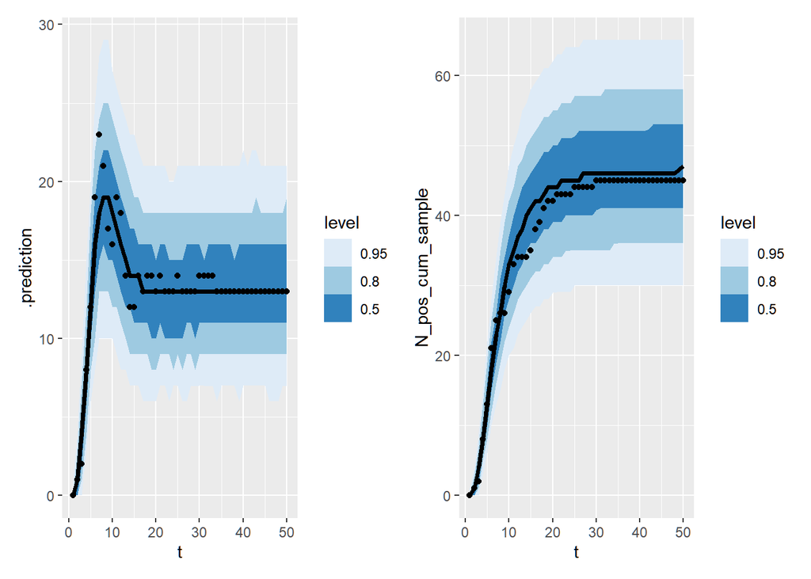

```r
# first have to define the helper function to generate the posterior

prep_data = prepare_predictions(model) # needed to extract both mv models prep data simultaneously
posterior_predict_binomsharedpars <- function(i, prep, ...) {
  # lambda = N_int(t,Upois,Ubin,mupois,sigmapois,mubin,sigmabin)
  # this is the current, most basic, approximate method for generating an estimate of N.

  Ubinom <- brms::get_dpar(prep, "mu", i = i)
  mubinom <- brms::get_dpar(prep, "mubin", i = i)
  sigmabinom <- brms::get_dpar(prep, "sigmabin", i = i)
  mupois <- prep_data$resps$Nposincrement$nlpars$mupois$fe$b
  sigmapoisstd <- prep_data$resps$Nposincrement$nlpars$sigmapoisstd$fe$b
  Upoisstd <- prep_data$resps$Nposincrement$nlpars$Upoisstd$fe$b
  Upois = exp(Upoisstd*0.3+4)
  sigmapois = exp(sigmapoisstd+1)
  t <- prep$data$vreal1[i] # vint(Nprev,N)+vreal(t,tprev)
  N_est = c()
  for (j in 1:prep$ndraws){
    N_est[j] = N_int(t,Upois[j],Ubinom[j],mupois[j],sigmapois[j],mubinom[j],sigmabinom[j])
  }

  rpois(prep$ndraws,N_est)
}

library(tidybayes)
library(plotly)
library(ggplot2)
library(patchwork)# allows for the side by side charting process that you see below
pred <- predicted_draws(model, newdata = standata)


N_plot = pred%>%filter(.category=="Nnegincrement")%>%
   ggplot(aes(x = t, y = .prediction)) +
  stat_lineribbon() +
  scale_fill_brewer() +
 geom_point(data = pred%>%filter(.category=="Nnegincrement"), aes(t, N))

N_pos_plot = pred%>%filter(.category=="Nposincrement")%>%
  group_by(.draw)%>%
  mutate(N_pos_cum_sample = cumsum(.prediction))%>%ungroup()%>%
   ggplot(aes(x = t, y = N_pos_cum_sample)) +
  stat_lineribbon() +
  scale_fill_brewer() +
 geom_point(data = standata, aes(t, N_pos))

N_plot + N_pos_plot
```

The overlay plots show that the model is following the data, but not fantastically well initially. At this point I realised that my priors did not cover the parameters that I selected very well and, after checking the development pattern I saw that the choices I made when I generated the data weren’t great, with much of the development still to be expected after month 50, which is not realistic. So I went back and chose what I thought were better parameters for the synthetic data. So the charts above are the result of improved synthetic data choices where development has halted by month 50 for both the binomial and poisson rate curves.

After an additional bug fix in predicted draws, the charts now look as they should. We can now move on to modelling real world data. So we conclude this chapter of the process as the real world data cannot be shared here.

# Conclusion

It is possible to construct an ODE model that can treat for negative IBNR (Incurred but not reported) claim count data. This treatment using a combination of Poisson and Binomial or just Poisson distributions can reasonably infer expected claim count development patterns when there are two competing processes to contend with: The first process is that of reporting claims and the second, where claims are rejected or fall below deductible and close with no payment.

This type of model is useful for claims reserving and pricing in the insurance sector and can be extended in several key ways using the BRMS/stan modelling architecture.

In the next section we will apply this model to a multi-level model to solve for a standard triangulation exercise.